# Sample lesson - Fitting and interpreting linear regression models in R

June 6, 2017

## Lesson context

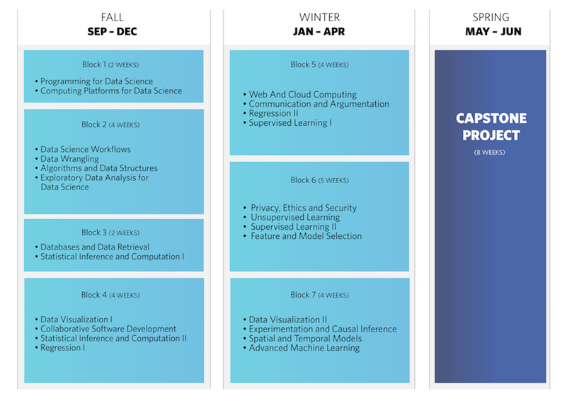

*source: [UBC MDS blog](https://ubc-mds.github.io/img/Course-Schedule-image.jpg)*

## Lesson context

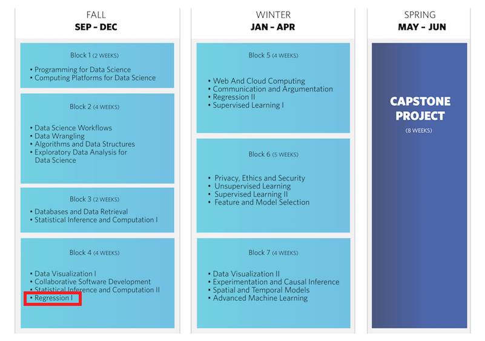

*source: [UBC MDS blog](https://ubc-mds.github.io/img/Course-Schedule-image.jpg)*

## DSCI 561 Regression I

*(taken from public description of UBC MDS course DSCI 561)*

### Short Description

Linear models for a quantitative response variable, with multiple categorical and/or quantitative predictors. Matrix formulation of linear regression. Model assessment and prediction.

## DSCI 561 Regression I

*(taken from public description of UBC MDS course DSCI 561)*

### Course Learning Outcomes

By the end of the course, students are expected to be able to:

- Fit and interpret a linear regression model.
- Identify whether a linear regression model is appropriate for a given dataset.
- Critique a specific regression model applied to a given dataset on the basis of both diagnostic plots and hypothesis tests.
- Specify and interpret interaction terms and nonlinear terms.

## DSCI 561 Regression I

*(adapted from public description of UBC MDS course DSCI 561)*

### Reference Materials

- Faraway, Julian J. Linear Models with R, 2nd Edition. Chapman and Hall, 2014.
- broom package in R

## Sample lesson: Fitting and interpreting linear regression models in R

1/4 of the way into the course. Before this lesson, students will have learned the following:

- model notation in R
- one-way ANOVA
- linear regression via ordinary least squares

## Sample lesson: Fitting and interpreting linear regression models in R

### 20 minute lesson learning objectives:

By the end of this lesson students are expected to be able to:

- fit a simple linear model in R
- interpret the output of the linear model object in R
- use three functions from the broom package extract linear model object output

## Lesson Motivation

## The Data:

from Data USA: https://datausa.io/

| display_name | income | mean_commute_minutes | median_property_value | non_eng_speakers_pct | owner_occupied_housing_units | pop |
| --- | --- | --- | --- | --- | --- | --- |
| Texas | 53207 | 24.5090 | 136000 | 0.3503480 | 0.622325 | 26538614 |
| Pennsylvania | 53599 | 25.2695 | 166000 | 0.1064820 | 0.692052 | 12779559 |
| South Carolina | 45483 | 23.0552 | 139900 | 0.0686766 | 0.685914 | 4777576 |
| New Hampshire | 66779 | 25.2973 | 237300 | 0.0786821 | 0.709609 | 1324201 |
| Kansas | 52205 | 18.2779 | 132000 | 0.1130530 | 0.666891 | 2892987 |
| Hawaii | 69515 | 25.5813 | 515300 | 0.2521790 | 0.569030 | 1406299 |

## Simple linear regression:

### State property value as a function of income

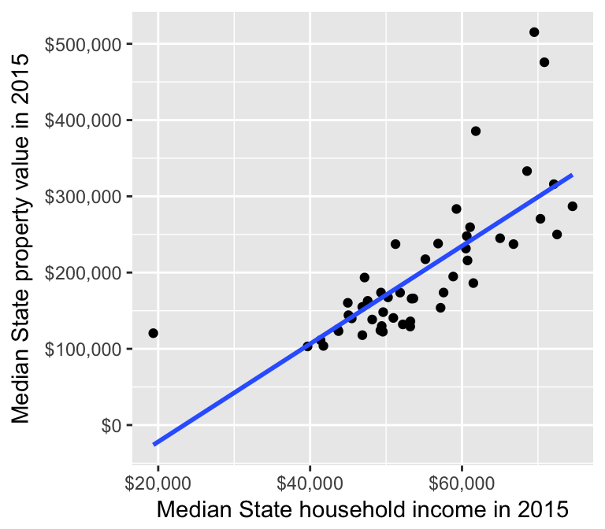

\(Y = \textrm{State}\: \textrm{median}\: \textrm{property}\: \textrm{value}\)  
\(X_{1} = \textrm{income}\)

## Model notation for linear regression in R

### Simple linear regression:

mathematical forumula:  
\(Y = \beta_{0} + \beta_{1}X_{1} + \varepsilon\)

model forumula in R:  
`Y ~ X1`

### More complex linear regression:

mathematical forumula:

\(Y = \beta_{0} + \beta_{1}X_{1} + \beta_{2}X_{2} + \beta_{3}X_{3} + \varepsilon\)

\(Y = \beta_{0} + \beta_{1}X_{1} + \beta_{2}X_{2} + \beta_{3}X_{1}X_{2} + \varepsilon\)

model forumula in R:

`Y ~ X1 + X2 + X3`

`Y ~ X1 * X2`

### Cheatsheet for model notation in R:

http://faculty.chicagobooth.edu/richard.hahn/teaching/formulanotation.pdf

## Syntax for linear regression in R

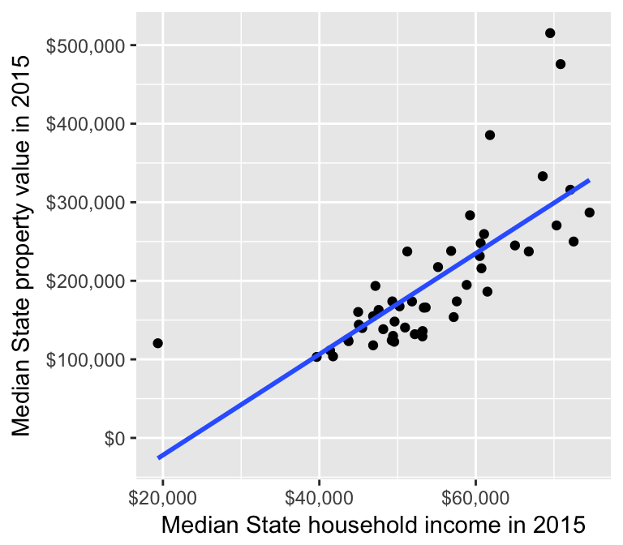

\(\textrm{State}\: \textrm{median}\: \textrm{property}\: \textrm{value} = \beta_{0} + \beta_{1}\textrm{income} + \varepsilon\)

`prop_model <- lm(median_property_value ~ income, data = prop_data)`

## Check-in question:

https://b.socrative.com/login/student/

room number: F321E8CC

## Syntax for simple linear regression

create linear model object:

```r
prop_model <- lm(median_property_value ~ income, data = prop_data)
```

print/view model object output:

```r
summary(prop_model)
```

```
##
## Call:
## lm(formula = median_property_value ~ income, data = prop_data)
##
## Residuals:
##    Min     1Q Median     3Q    Max
## -65249 -36542  -6990   8003 219312
##
## Coefficients:
##               Estimate Std. Error t value Pr(>|t|)
## (Intercept) -1.503e+05  4.393e+04  -3.422  0.00125 **
## income       6.420e+00  7.999e-01   8.026 1.52e-10 ***
## ---
## Signif. codes:  0 '***' 0.001 '**' 0.01 '*' 0.05 '.' 0.1 ' ' 1
##
## Residual standard error: 58860 on 50 degrees of freedom
## Multiple R-squared:  0.563,  Adjusted R-squared:  0.5542
## F-statistic: 64.41 on 1 and 50 DF,  p-value: 1.517e-10
```

## Decoding R’s output from `summary()`:

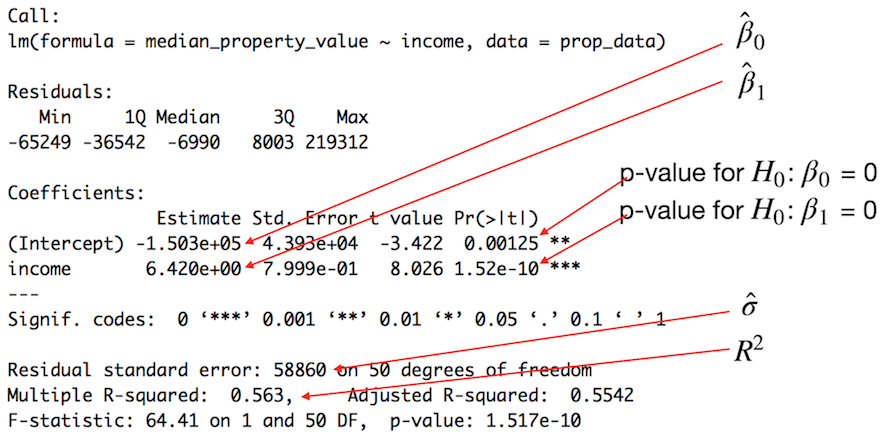

## Extracting output from model object in base R:

[output not shown]

### The good…

- all the information you want it there
- this has been used for many many many years and thus should be familiar to most Data
- Scientists and Statisticians

### The bad…

- inconsistent syntax to extract model output
- model output is returned in a variety of forms, and is not tidy data

### The ugly…

- bizarre symbols in some column names (e.g., summary(model_object)$coefficient)
- F-statistic p-value is never stored in memory and thus must be calculated by hand

`broom`:

[figure not shown]

A better way for working with model output in R